# Potential general framework

# 1 Without multilayer approach

Pilot aggregating different habitats to create different management scenarios.

Here, we compared Ecosystem services provided by Extensive and Intensive habitat management.

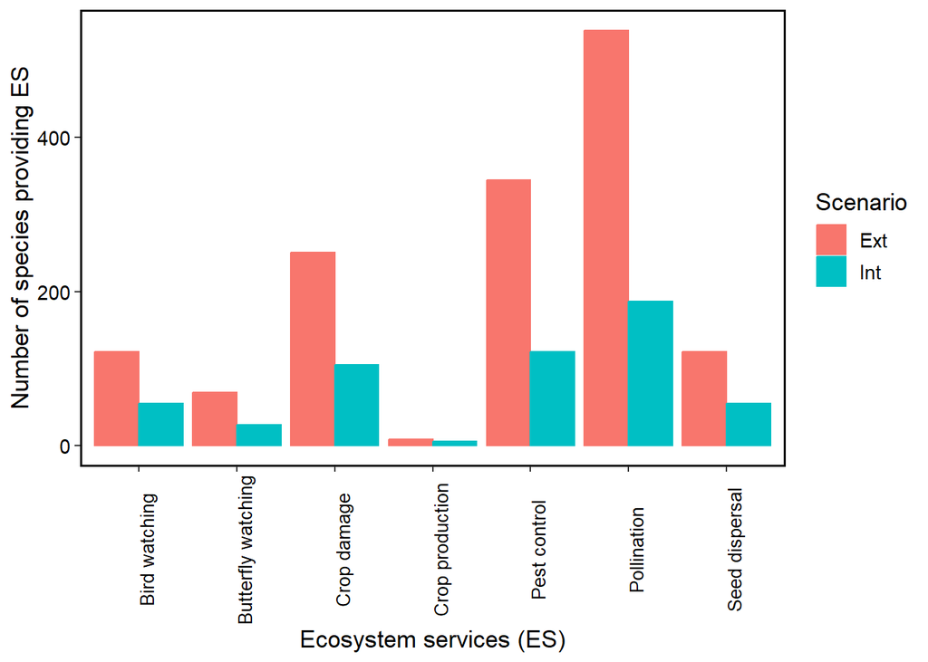

# 2 With multilayer approach

We built a multilayer network containing:

- Layers: Habitats
- Nodes: Species with attributes (attr: trophic groups and provided ecosystem services)
- Weighted intralayer links between trophic groups. Weight: product of the densities of species involved, scaled by the overall area covered by the habitat on the farm.

## 2.1 Nodes per habitat

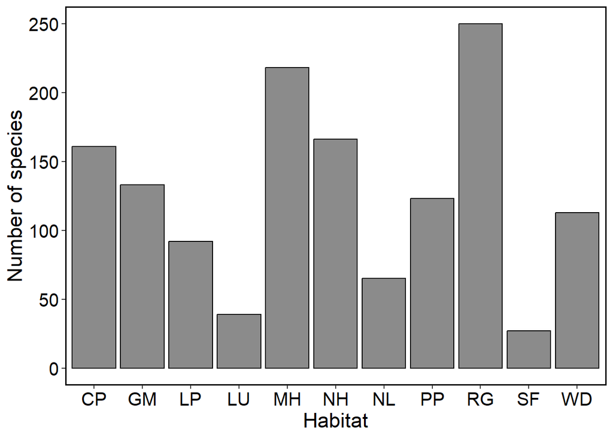

## 2.2 Nodes per habitat and trophic group

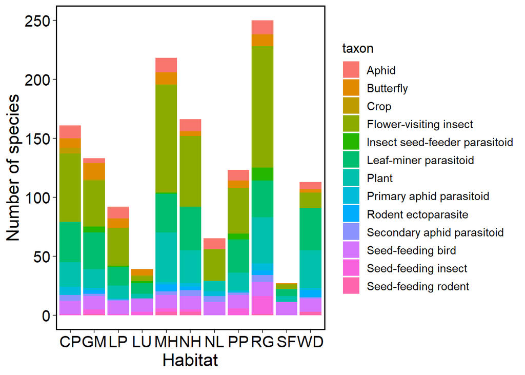

## 2.3 ES provided per taxon

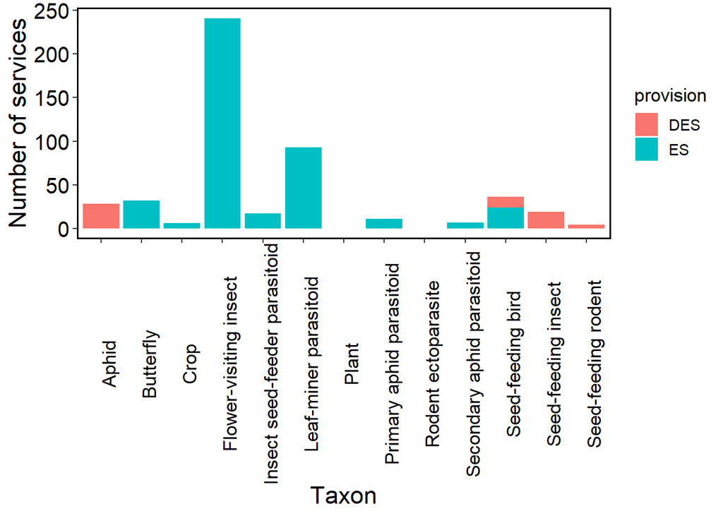

## 2.4 ES per habitat

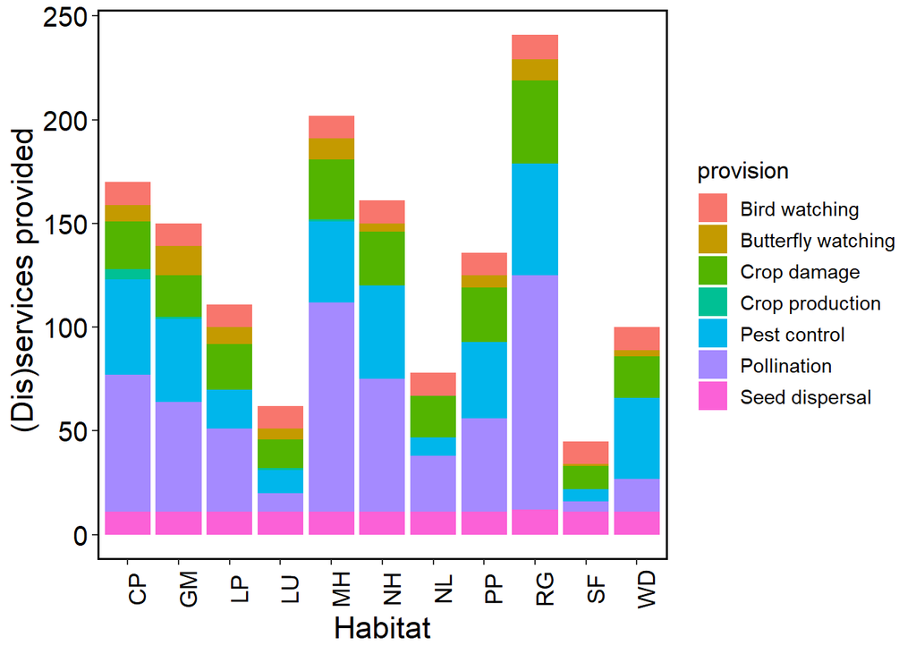

## 2.5 Link’s distribution

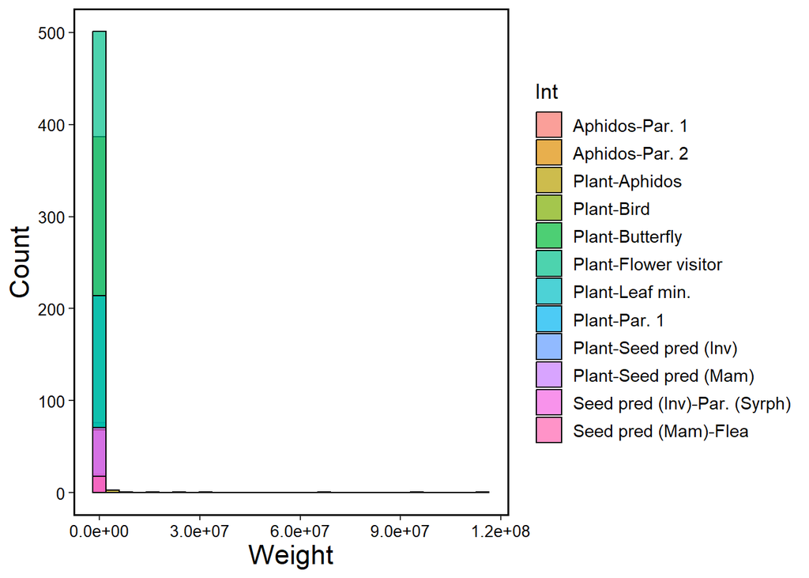

## 2.6 Distribution of modules across habitats

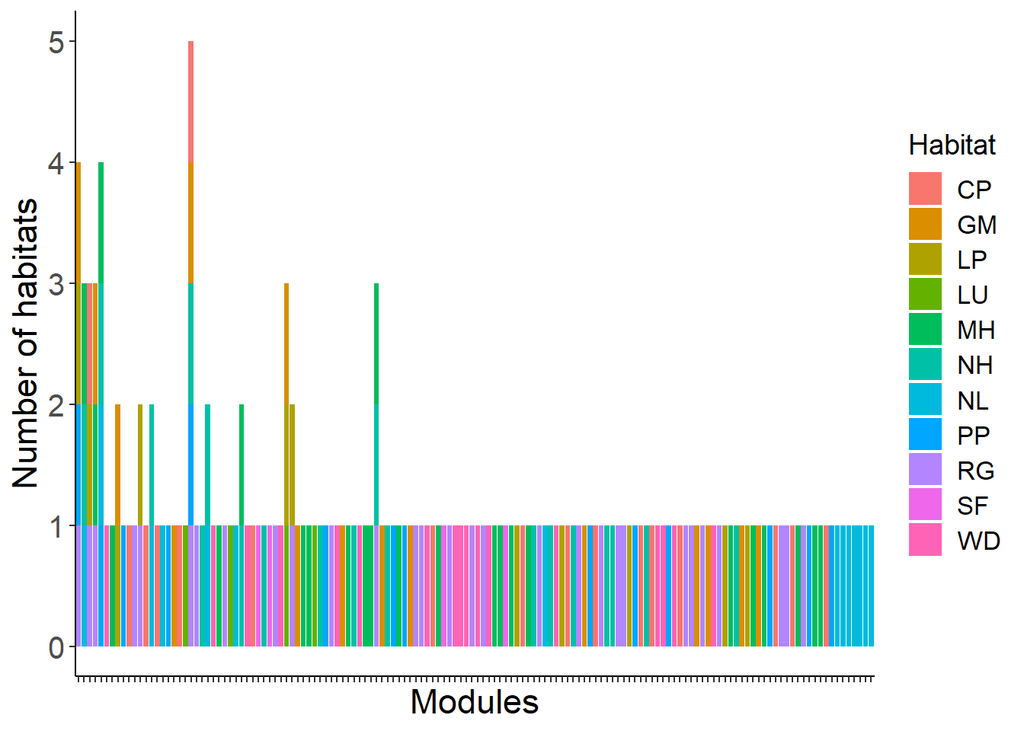

## 2.7 Modules’ size

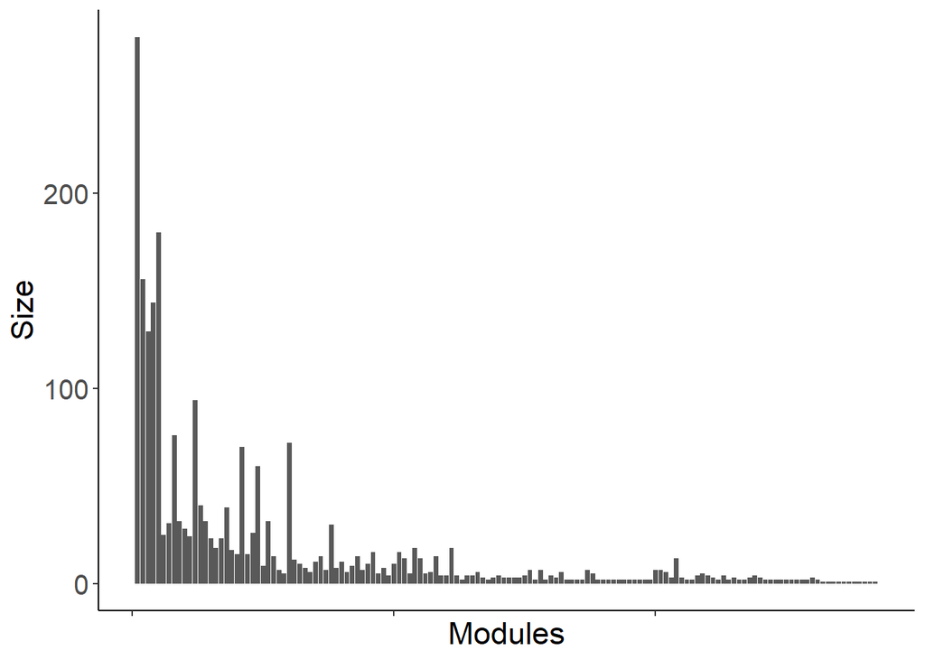

## 2.8 Modules’composion (trophic group)

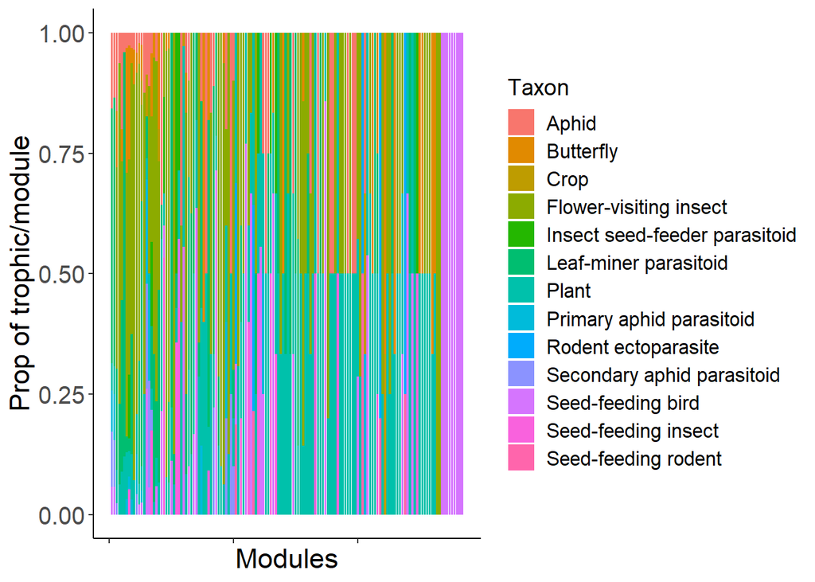

## 2.9 Modules’composion (ES)

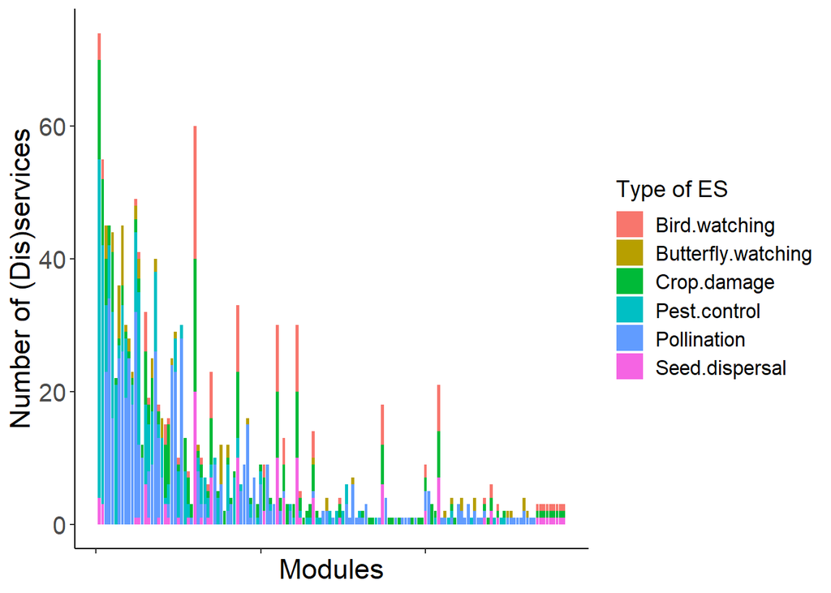

# 3 Direct and indirect effects of ES

We calculated the direct ES provide by each species and its indirect effect on other ESs

## 3.1 Number and prop ES/hab

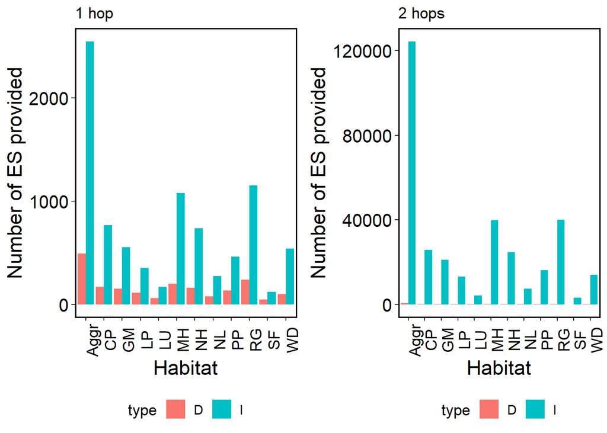

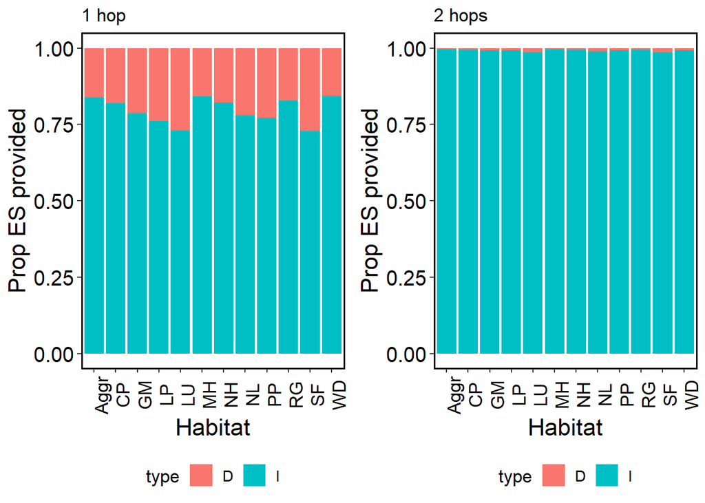

## 3.2 Prop. ES per taxon/habitat

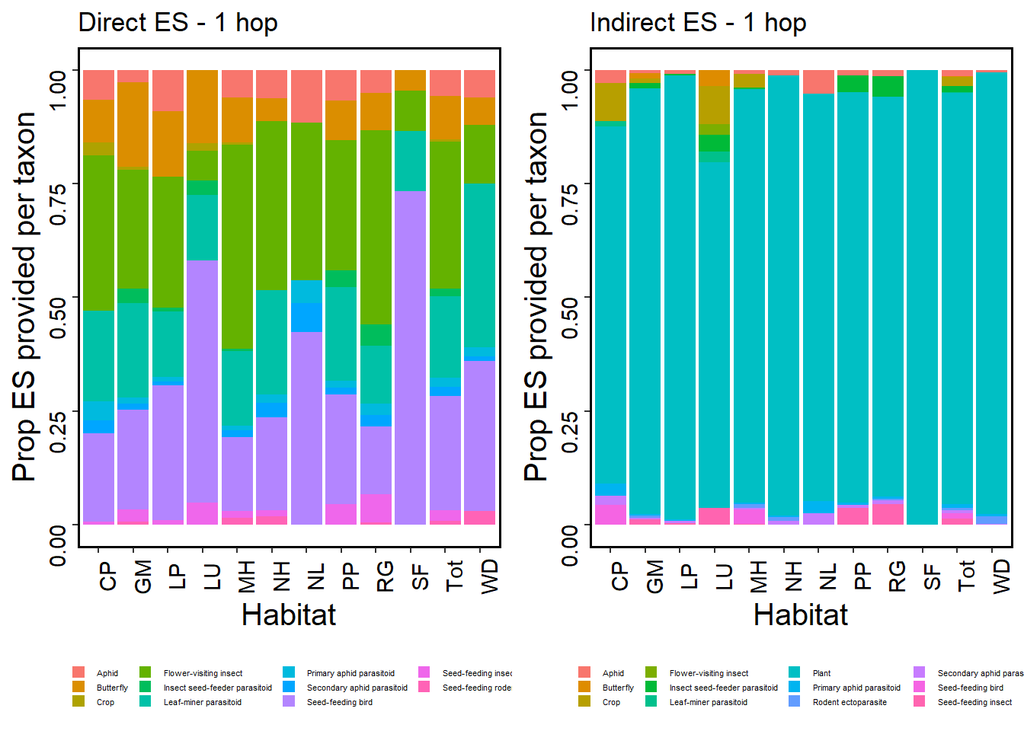

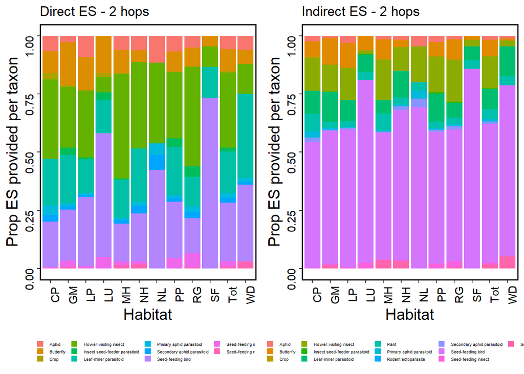

## 3.3 Prop. ES provided per services /habitat

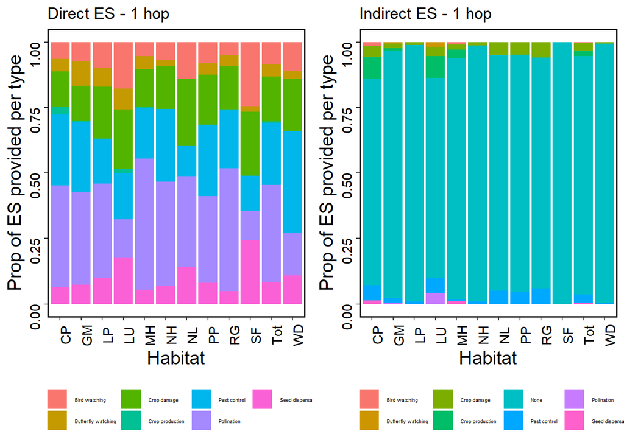

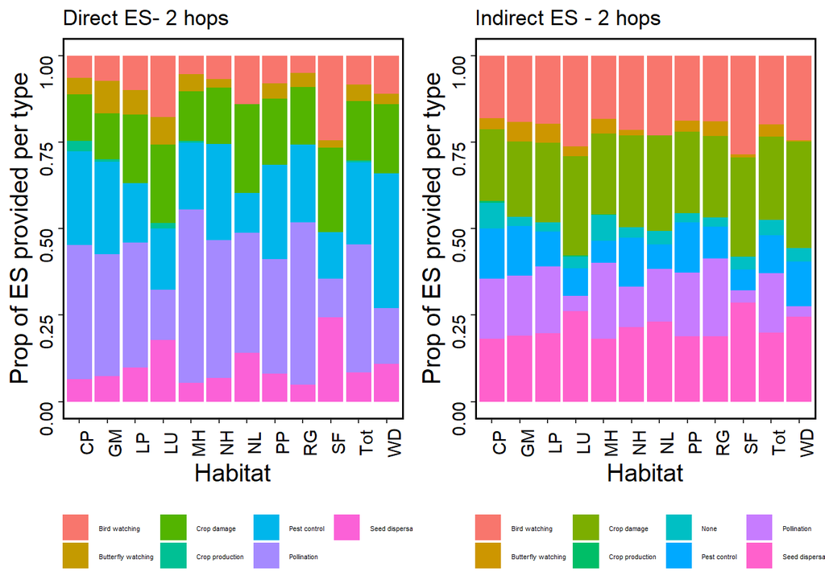

## 3.4 Sps importance

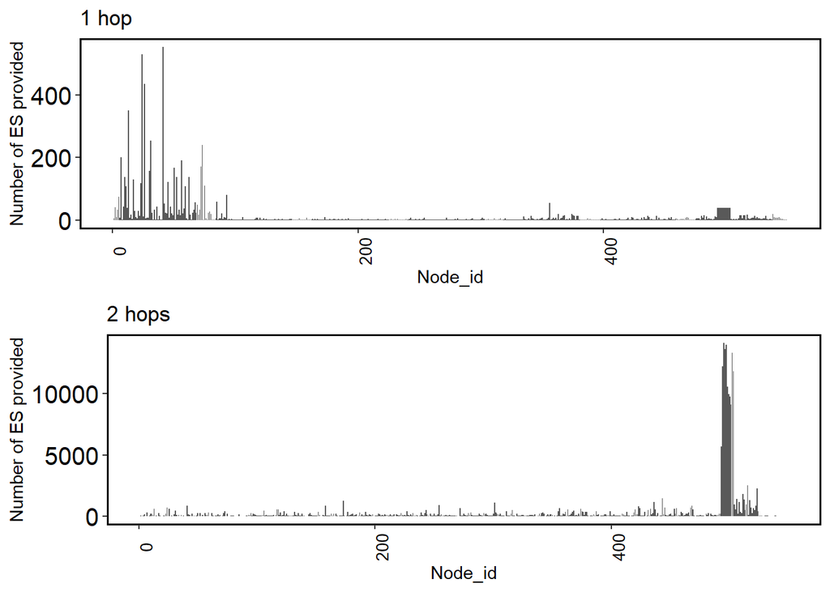

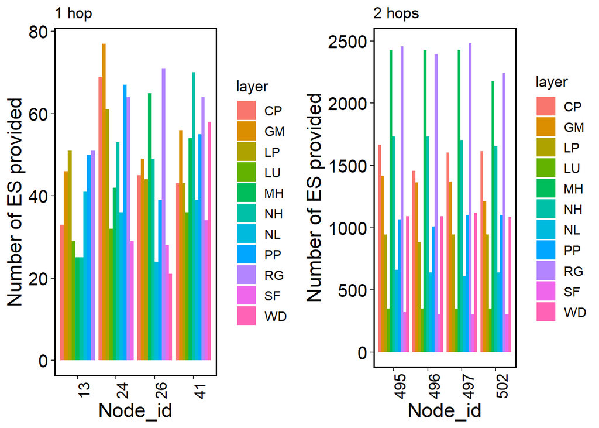

# 4 Next steps…

- Effects of nodes on ESs (direct and indirect) instead of ES-ES
- Ask Shai how attributes work (explain modularity).
- When we calculate the quantity of ES provided we can include abundance (as attributes of state nodes) and size of the species (e.g., small, medium, big as attributes of nodes). This would help to control for taxon groups with great abundance such as insects. It could be the product between abundance and size (small = 0.1, medium = 0.5, big =1).
- Intraedges between 0 and 1. Let’s suppose we have an aphid species A and a plant species B in a specific habitat. The weight of A-B will be equal to: the product of their abundances / product of abundances of between all aphid and plant species in the specific habitat. Abundance instead of density. RELATIVE ABUNDANCES
- Interedges?
- Extinction scenarios: Which kind of approach we want to use? create different multilayer according to the habitat management or simulate the change in habitat management with the extinction models?
- Igraph guide

TO DO:

- Change graphs to proportion

DUDA: Multilayer:

- 2 layers: phy - spi & spi - bird
- Intralayer links: weighted predation interaction
- Interlayer links: indirect interaction between species (for example, from bird to phy)

Is it necessary to link spiders between layers? otherwise, modules will jump from phy to birds. In the case it is necessary, can interlayer liks represent different things? put the meaning in link’s attributes